# Team 2 - Lab 2

MARSS models

Brian McGreal, Lilac Hong, Emma Christman

April 23, 2025

# Data

As team 2, we were assigned the Snake River Spring and Summer Run Chinook Data. This data contains infromation on 28 different populations of Chinkook. Each population falls into one of three runs, (spring, spring/summer, and summer) and into one of five major populations. When separated by run timing and major population, nine distinct grouping emerge.

Load the data.

Wrangle the data.

```
## # A tibble: 6 × 8
##   species      esu_dps majorpopgroup esapopname commonpopname run   spawningyear
##   <chr>        <chr>   <chr>         <chr>      <chr>         <chr>        <int>
## 1 Chinook sal… Salmon… Cascade fall  Salmon, C… Clackamas Ri… Fall          1964
## 2 Chinook sal… Salmon… Cascade fall  Salmon, C… Clackamas Ri… Fall          1965
## 3 Chinook sal… Salmon… Cascade fall  Salmon, C… Clackamas Ri… Fall          1966
## 4 Chinook sal… Salmon… Cascade fall  Salmon, C… Clackamas Ri… Fall          1967
## 5 Chinook sal… Salmon… Cascade fall  Salmon, C… Clackamas Ri… Fall          1968
## 6 Chinook sal… Salmon… Cascade fall  Salmon, C… Clackamas Ri… Fall          1969
## # ℹ 1 more variable: value <dbl>
```

```
##   Year     annual   pdo_03ya spawningyear
## 1 1946 -0.4341667         NA         1947
## 2 1947  0.4175000         NA         1948
## 3 1948 -0.9008333 -0.3058333         1949
## 4 1949 -1.7433333 -0.7422222         1950
## 5 1950 -2.2358333 -1.6266667         1951
## 6 1951 -1.1216667 -1.7002778         1952
```

# General Questions

1. Create estimates of spawner abundance for all missing years and provide estimates of the decline from the historical abundance.
2. Evaluate support for the major population groups. Are the populations in the groups more correlated than outside the groups?
3. Evaluate the evidence of cycling in the data.

As a group, we’ve decided to dig into the estimates during the missing years, as outlined in the first question, as well as investigate the relationship between the different populations to see how they are/are not correlated. This comes from the second question, to which we are investigating not only the role of major population group, but run timing, and esa population name. This is allowing us to test several hypotheses:

H1: There is no difference between any of the groups (observing the same population different rivers and times)

H2: There is a difference between all of the separate esa populations, major populations, and run timing, meaning 28 different populations

H3: The same as H2, however there is temporal correlation

H4a and b: Run timing is the only distinguishing factor, meaning that there are only 3 correlated populations (and are temporally correlated or not correlated, 2 models)

H5a and b: Major population groups is the only distinguishing factor, meaning that there are only 5 correlated populations (and are temporally correlated or not correlated, 2 models)

H6a and b: Major population group and run timing are the distinguishing factors, meaning that there are 9 correlated populations (and are temporally correlated or not correlated, 2 models).

# Methods

Assumptions about x and how the data time series are related to x:

We assumed different model structures in terms of x and y relationship:

- One x for all populations (A single hidden state shared across all populations) (H1).
- One x per population (each population has its own hidden state) (H2, H3).
- One x per run group (spring, spring/summer, summer) (H4).
- One x per major population group (e.g., Lower Snake, Middle Fork Salmon, etc.) (H5).
- One x per major population group + run combo (e.g., “Lower Snake, Spring”) (H6).

Specifically, write out the assumptions in matrix form:

## Hypothesis 1

$$\begin{bmatrix}
y_1 \\
y_2 \\
\vdots \\
y_{28}
\end{bmatrix}_t
=
\begin{bmatrix}
1 \\
1 \\
\vdots \\
1
\end{bmatrix}
x_t
+
\begin{bmatrix}
0 \\
0 \\
\vdots \\
0
\end{bmatrix}
+
\begin{bmatrix}
v_1 \\
v_2 \\
\vdots \\
v_{28}
\end{bmatrix}_t \text{where} \textbf{v}_t \sim \mathcal{N}(0,\textbf{R})
\\$$

$$x_t = Bx_{t-1} + u + w_t \text{where} w_t \sim \mathcal{N}(0,q)$$

where $\textbf{R}$ is `"diagonal and equal"`, i.e.

$$\textbf{R} =
\begin{bmatrix}
r & 0 & \cdots & 0 \\
0 & r & \cdots & 0 \\
\vdots & \vdots & \ddots & \vdots \\
0 & 0 & \cdots & r
\end{bmatrix}$$

## Hypothesis 2 & 3

$$\begin{bmatrix}
y_1 \\
y_2 \\
\vdots \\
y_{28}
\end{bmatrix}_t
=
\begin{bmatrix}
1 & 0 & \cdots & 0 \\
0 & 1 & \cdots & 0 \\
\vdots & \vdots & \ddots & \vdots \\
0 & 0 & \cdots & 1
\end{bmatrix}
\begin{bmatrix}
x_1 \\
x_2 \\
\vdots \\
x_{28}
\end{bmatrix}_t
+
\begin{bmatrix}
0 \\
0 \\
\vdots \\
0
\end{bmatrix}
+
\begin{bmatrix}
v_1 \\
v_2 \\
\vdots \\
v_{28}
\end{bmatrix}_t \; \text{where} \: \textbf{v}_t \sim
\mathcal{N}(0,\textbf{R}) \\$$

$$\begin{bmatrix}
x_1 \\
x_2 \\
\vdots \\
x_{28}
\end{bmatrix}_t
=
\begin{bmatrix}
1 & 0 & \cdots & 0 \\
0 & 1 & \cdots & 0 \\
\vdots & \vdots & \ddots & \vdots \\
0 & 0 & \cdots & 1
\end{bmatrix}
\begin{bmatrix}
x_1 \\
x_2 \\
\vdots \\
x_{28}
\end{bmatrix}_{t-1}
+
\begin{bmatrix}
u \\
u \\
\vdots \\
u
\end{bmatrix}
+
\begin{bmatrix}
w_1 \\
w_2 \\
\vdots \\
w_{28}
\end{bmatrix}_t \; \text{where} \: \textbf{w}_t \sim
\mathcal{N}(0,\textbf{Q})$$

where $\textbf{R}$ is `"diagonal and equal"` and $\textbf{Q}$ is `"diagonal and equal"` in H2:

$$\textbf{Q} =
\begin{bmatrix}
q & 0 & \cdots & 0 \\
0 & q & \cdots & 0 \\
\vdots & \vdots & \ddots & \vdots \\
0 & 0 & \cdots & q
\end{bmatrix}$$

Or, $\textbf{Q}$ is `"equalvarcov"` in H3:

$$\textbf{Q} =
\begin{bmatrix}
q & c & \cdots & c \\
c & q & \cdots & c \\
\vdots & \vdots & \ddots & \vdots \\
c & c & \cdots & q
\end{bmatrix}$$

## Hypothesis 4

Three hidden states based on run group (Spring, Spring/Summer, Summer).

$$\begin{bmatrix}
y_1 \\
y_2 \\
y_3 \\
\vdots \\
y_{28}
\end{bmatrix}_t
=
\begin{bmatrix}
1 & 0 & 0 \\
1 & 0 & 0 \\
\vdots & \vdots & \vdots \\
0 & 1 & 0 \\
0 & 0 & 1
\end{bmatrix}
\begin{bmatrix}
x_1 \\
x_2 \\
x_3
\end{bmatrix}_t
+
\begin{bmatrix}
0 \\
0 \\
0 \\
\vdots \\
0
\end{bmatrix}
+
\begin{bmatrix}
v_1 \\
v_2 \\
v_3 \\
\vdots \\
v_{28}
\end{bmatrix}_t \; \text{where} \: \textbf{v}_t \sim
\mathcal{N}(0,\textbf{R}) \\$$

$$\begin{bmatrix}
x_1 \\
x_2 \\
x_3
\end{bmatrix}_t
=
\begin{bmatrix}
1 & 0 & 0 \\
0 & 1 & 0 \\
0 & 0 & 1
\end{bmatrix}
\begin{bmatrix}
x_1 \\
x_2 \\
x_3
\end{bmatrix}_{t-1}
+
\begin{bmatrix}
u \\
u \\
u
\end{bmatrix}
+
\begin{bmatrix}
w_1 \\
w_2 \\
w_3
\end{bmatrix}_t \; \text{where} \: \textbf{w}_t \sim
\mathcal{N}(0,\textbf{Q})$$

where $\textbf{R}$ is `"diagonal and equal"` and $\textbf{Q}$ is `"equalvarcov"` in H4a and `"diagonal and equal"` in H4b.

## Hypothesis 5 & 6

H5 examines five hidden states based on major population groups (“Grande Ronde/Imnaha”, “Lower Snake”, “Middle Fork Salmon”, “South Fork Salmon”, “Upper Salmon” ).

The model retains the same general structure as before, with the dimension of $\textbf{x}_t$ varying depending on the number of hidden states assumed. We also assume that $\textbf{R}$ is `"diagonal and equal"` and $\textbf{Q}$ is `"equalvarcov"` in scenario a`"diagonal and equal"` in scenario b.

## Summary

In summary, the general form of multivariate state-space models in the MARSS package is:

$$\textbf{x}_t = \textbf{Bx}_{t-1} + \textbf{u} + \textbf{w}_t \;
\text{where} \: \textbf{w}_t \sim \mathcal{N}(0,\textbf{Q})\\
\textbf{y}_t = \textbf{Zx}_t + \textbf{a} + \textbf{v}_t \; \text{where}
\: \textbf{v}_t \sim \mathcal{N}(0,\textbf{R}) \\
\textbf{x}_0 = \boldsymbol{\mu}$$

After fitting the different models, we compare them with AICc.

# Results

## Hypothesis Testing

### Hypothesis 1

Hypothesis 1 considers all 28 populations as samples drawn from one all encompassing state process.

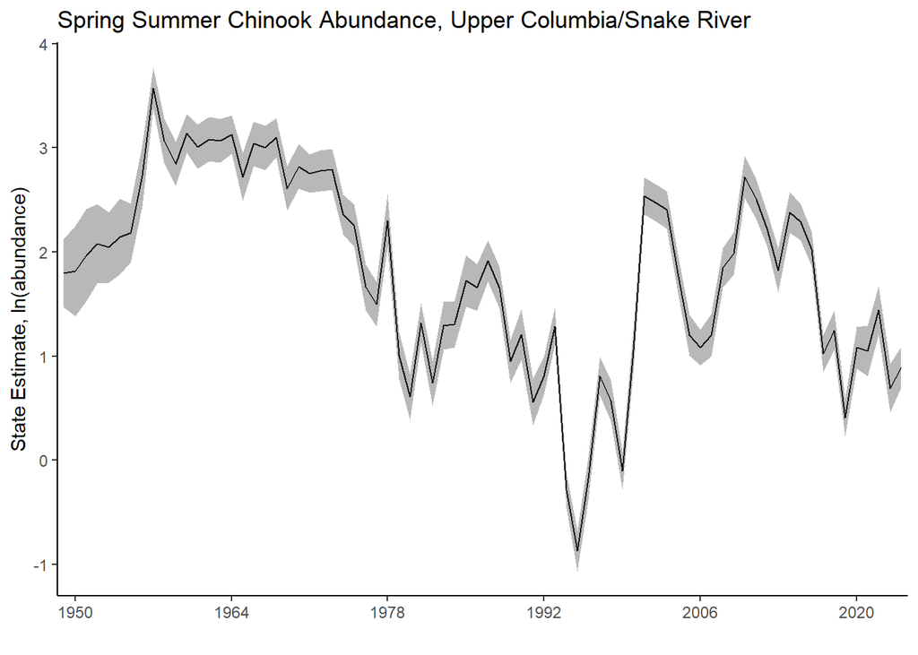

### Hypothesis 2

Hypothesis 2 considers all 28 populations as each sampled from a distinct underlying state process, each with the same variance.

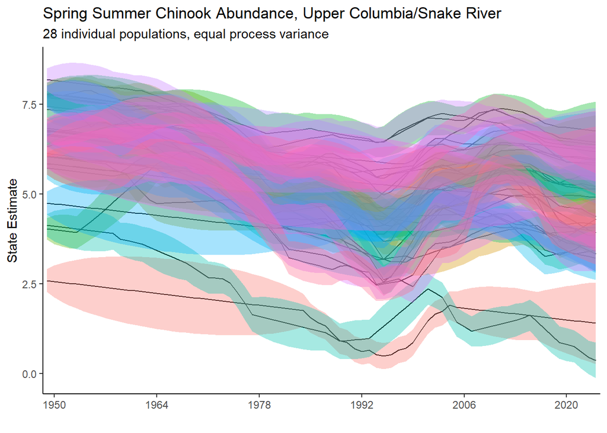

### Hypothesis 3

Hypothesis 3 considers all 28 populations as each sampled from a distinct underlying state process, each with the same variance and equal covariance between all underlying states (allowing for temporal correlation).

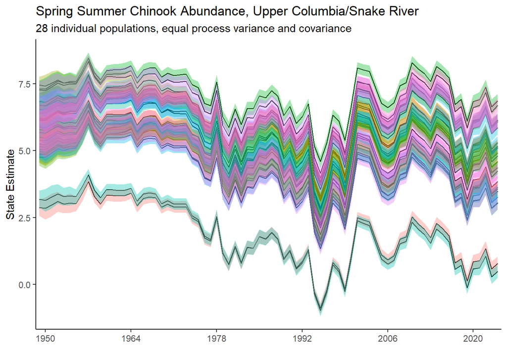

### Hypothesis 4a

Hypothesis 4a considers all 28 populations as samples from three distinct underlying state process representing different run timing. Each of these runs is modeled with the same variance and equal covariance, allowing for temporal correlation.

Variance-covariance matrix of fitted state estimates included below.

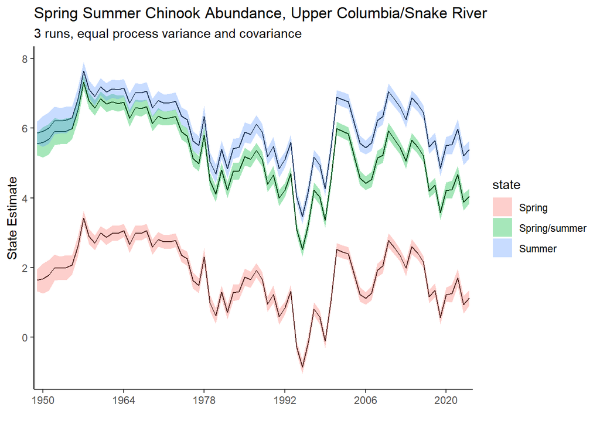

```
## [1] "Spring"        "Spring/summer" "Summer"
```

```
##           [,1]      [,2]      [,3]
## [1,] 1.0000000 0.9676629 0.9924417
## [2,] 0.9676629 1.0000000 0.9531519
## [3,] 0.9924417 0.9531519 1.0000000
```

### Hypothesis 4b

Hypothesis 4b considers all 28 populations as samples from three distinct underlying state process representing different run timing. Each of these runs is modeled with the same variance and no covariance.

Variance-covariance matrix of fitted state estimates included below.

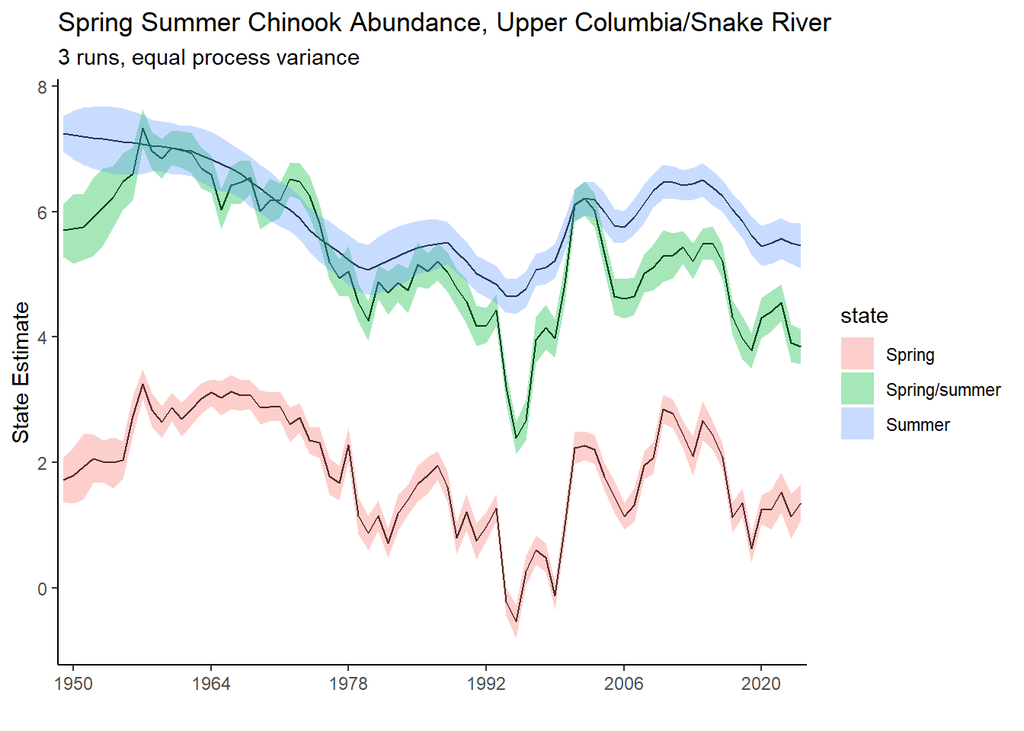

```
## [1] "Spring"        "Spring/summer" "Summer"
```

```
##           [,1]      [,2]      [,3]
## [1,] 1.0000000 0.8964725 0.7591673
## [2,] 0.8964725 1.0000000 0.8120748
## [3,] 0.7591673 0.8120748 1.0000000
```

### Hypothesis 5a

Hypothesis 5a considers all 28 populations as samples from five distinct underlying state process representing different major population groups. Each of these runs is modeled with the same variance and equal covariance, allowing for temporal correlation.

Variance-covariance matrix of fitted state estimates included below.

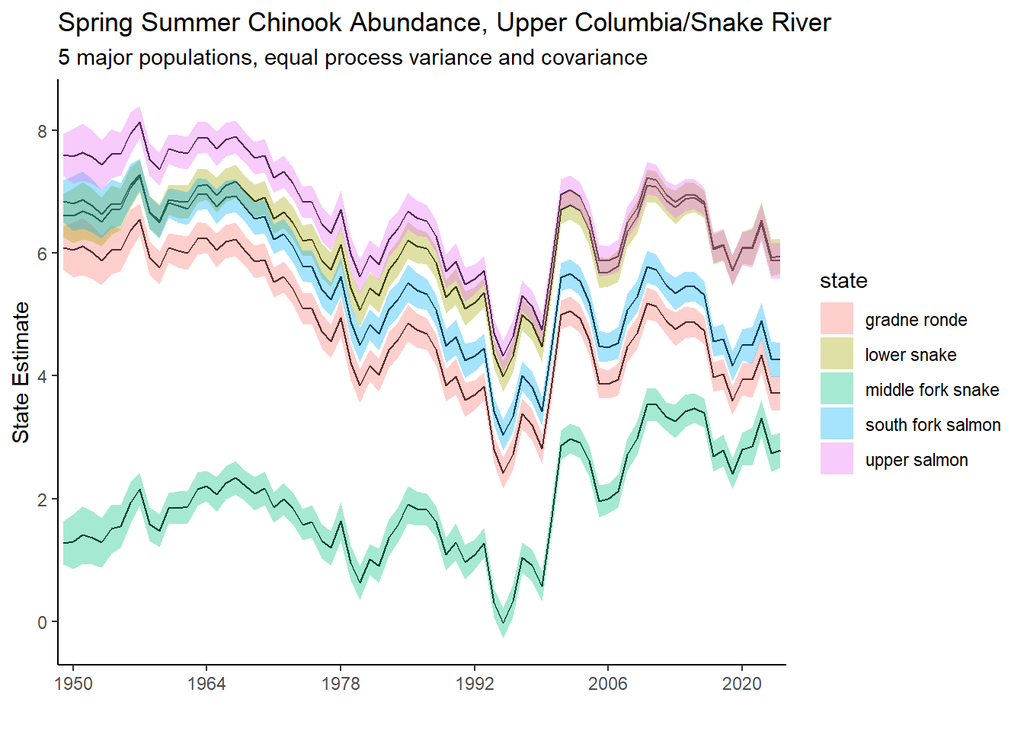

```
## [1] "lower snake"       "middle fork snake" "gradne ronde"
## [4] "upper salmon"      "south fork salmon"
```

```
##           [,1]      [,2]      [,3]      [,4]      [,5]
## [1,] 1.0000000 0.6840817 0.8860346 0.9452770 0.8673450
## [2,] 0.6840817 1.0000000 0.2679566 0.4086738 0.2303188
## [3,] 0.8860346 0.2679566 1.0000000 0.9888107 0.9992407
## [4,] 0.9452770 0.4086738 0.9888107 1.0000000 0.9822672
## [5,] 0.8673450 0.2303188 0.9992407 0.9822672 1.0000000
```

### Hypothesis 5b

Hypothesis 5b considers all 28 populations as samples from five distinct underlying state process representing different major population groups. Each of these major populations is modeled with the same variance and no covariance.

Variance-covariance matrix of fitted state estimates included below.

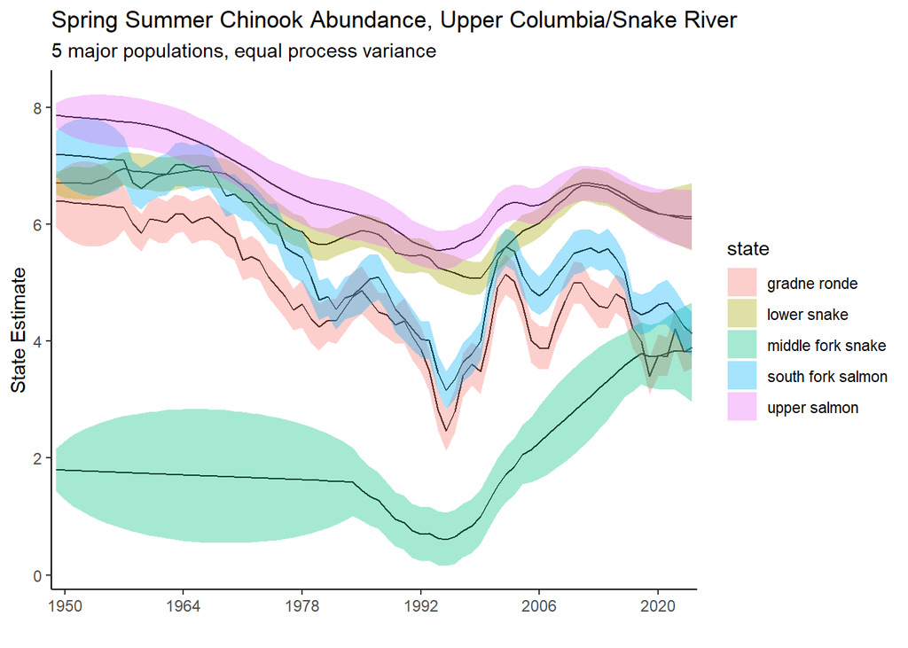

```
## [1] "lower snake"       "middle fork snake" "gradne ronde"
## [4] "upper salmon"      "south fork salmon"
```

```
##           [,1]         [,2]       [,3]       [,4]        [,5]
## [1,] 1.0000000  0.399786425  0.8139805 0.88898524 0.856066067
## [2,] 0.3997864  1.000000000 -0.0439751 0.08537519 0.007371194
## [3,] 0.8139805 -0.043975102  1.0000000 0.93569205 0.973994068
## [4,] 0.8889852  0.085375187  0.9356920 1.00000000 0.961810204
## [5,] 0.8560661  0.007371194  0.9739941 0.96181020 1.000000000
```

### Hypothesis 6a

Hypothesis 6a considers all 28 populations as samples from one of nine distinct underlying state process representing different run timing within different majopr population groups. Each of these runs is modeled with the same variance and equal covariance, allowing for temporal correlation.

Variance-covariance matrix of fitted state estimates included below.

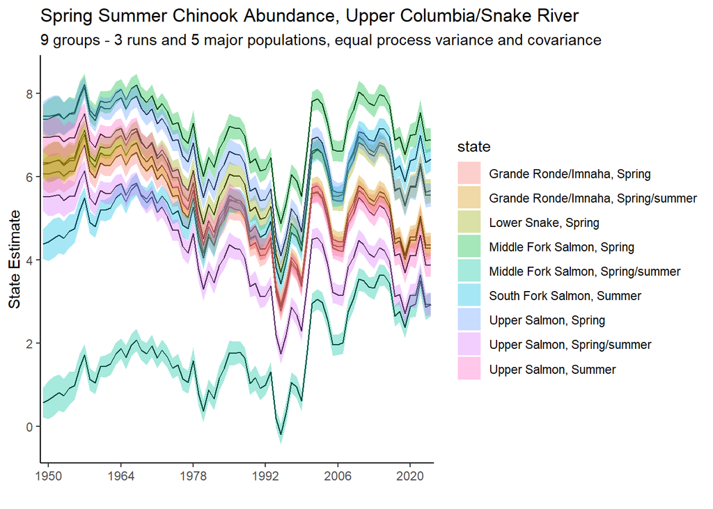

```
## [1] "Lower Snake, Spring"                "Middle Fork Salmon, Spring"
## [3] "Middle Fork Salmon, Spring/summer"  "Grande Ronde/Imnaha, Spring"
## [5] "Upper Salmon, Spring/summer"        "South Fork Salmon, Summer"
## [7] "Grande Ronde/Imnaha, Spring/summer" "Upper Salmon, Spring"
## [9] "Upper Salmon, Summer"
```

```
##            [,1]      [,2]         [,3]      [,4]        [,5]        [,6]
##  [1,] 1.0000000 0.9983229  0.490976020 0.9418556 0.871799167 0.557141793
##  [2,] 0.9983229 1.0000000  0.540524390 0.9208492 0.842021826 0.604223464
##  [3,] 0.4909760 0.5405244  1.000000000 0.1697029 0.001286624 0.996971485
##  [4,] 0.9418556 0.9208492  0.169702869 1.0000000 0.985709099 0.245713971
##  [5,] 0.8717992 0.8420218  0.001286624 0.9857091 1.000000000 0.078935108
##  [6,] 0.5571418 0.6042235  0.996971485 0.2457140 0.078935108 1.000000000
##  [7,] 0.9259698 0.9025880  0.125692163 0.9990075 0.992224962 0.202338380
##  [8,] 0.9328542 0.9104733  0.144192534 0.9996589 0.989732232 0.220593798
##  [9,] 0.8325946 0.7991842 -0.073720537 0.9702946 0.997177685 0.003932863
##            [,7]      [,8]         [,9]
##  [1,] 0.9259698 0.9328542  0.832594587
##  [2,] 0.9025880 0.9104733  0.799184158
##  [3,] 0.1256922 0.1441925 -0.073720537
##  [4,] 0.9990075 0.9996589  0.970294635
##  [5,] 0.9922250 0.9897322  0.997177685
##  [6,] 0.2023384 0.2205938  0.003932863
##  [7,] 1.0000000 0.9998195  0.980100079
##  [8,] 0.9998195 1.0000000  0.976224958
##  [9,] 0.9801001 0.9762250  1.000000000
```

### Hypothesis 6b

Hypothesis 6b considers all 28 populations as samples from one of nine distinct underlying state process representing different run timing within different majopr population groups. Each of these runs is modeled with the same variance and no covariance.

Variance-covariance matrix of fitted state estimates included below.

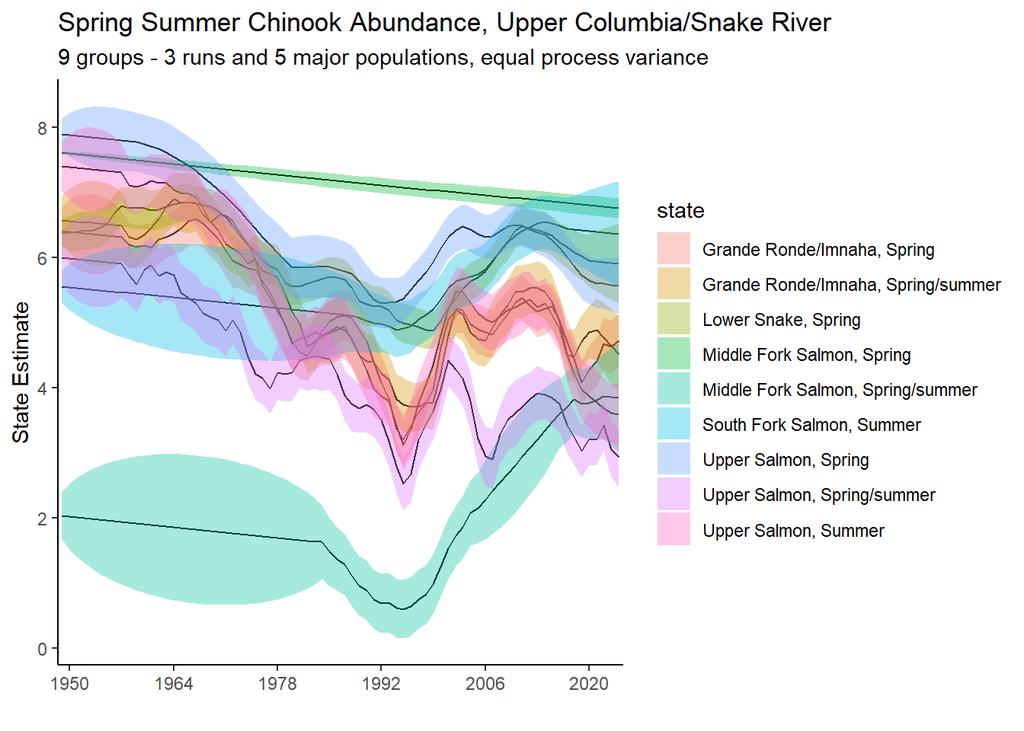

```
## [1] "Lower Snake, Spring"                "Middle Fork Salmon, Spring"
## [3] "Middle Fork Salmon, Spring/summer"  "Grande Ronde/Imnaha, Spring"
## [5] "Upper Salmon, Spring/summer"        "South Fork Salmon, Summer"
## [7] "Grande Ronde/Imnaha, Spring/summer" "Upper Salmon, Spring"
## [9] "Upper Salmon, Summer"
```

```
##            [,1]       [,2]        [,3]          [,4]       [,5]          [,6]
##  [1,] 1.0000000  0.4782023  0.42930435  0.8756172656  0.6885347  0.3247512520
##  [2,] 0.4782023  1.0000000 -0.46983594  0.7308859565  0.8930524 -0.5889694359
##  [3,] 0.4293043 -0.4698359  1.00000000  0.1048172100 -0.1444975  0.9498910472
##  [4,] 0.8756173  0.7308860  0.10481721  1.0000000000  0.8744396 -0.0005267736
##  [5,] 0.6885347  0.8930524 -0.14449748  0.8744395660  1.0000000 -0.2566073083
##  [6,] 0.3247513 -0.5889694  0.94989105 -0.0005267736 -0.2566073  1.0000000000
##  [7,] 0.8885902  0.7447526  0.11400104  0.9718183742  0.8815420  0.0033572404
##  [8,] 0.8051045  0.7702459  0.04149051  0.9017063116  0.9004448 -0.0101591426
##  [9,] 0.8001674  0.8249705 -0.04303446  0.9508187707  0.9354488 -0.1147183443
##             [,7]        [,8]        [,9]
##  [1,] 0.88859016  0.80510450  0.80016739
##  [2,] 0.74475257  0.77024585  0.82497049
##  [3,] 0.11400104  0.04149051 -0.04303446
##  [4,] 0.97181837  0.90170631  0.95081877
##  [5,] 0.88154198  0.90044482  0.93544881
##  [6,] 0.00335724 -0.01015914 -0.11471834
##  [7,] 1.00000000  0.91144593  0.94673618
##  [8,] 0.91144593  1.00000000  0.97107405
##  [9,] 0.94673618  0.97107405  1.00000000
```

### Model Comparison

```
##    Model     AICc
## 1  fit.1 2110.892
## 2  fit.2 2543.560
## 3  fit.3 2094.651
## 4 fit.4a 2100.727
## 5 fit.4b 2209.098
## 6 fit.5a 2666.865
## 7 fit.5b 2769.555
## 8 fit.6a 2597.828
## 9 fit.6b 2769.838
```

Our results suggest a preference for model 3, although model 4a shows comparable performance based on a slightly higher AICc score.

## Covariates

### PDO

We introduced pacficic decadal oscilation (PDO) data as a measure of ocean climate to the two most parsimonious models as selected by AICc (models 3 and 4a). We used the average PDO across the three years prior to the spawning year recorded in each observation as representation of the ocean climate during the period in which these Chinook would have been adults at sea.

### Model 3 with PDO

Model 3 treats all 28 populations as each sampled from a distinct underlying state process, each with the same variance and equal covariance between all underlying states (allowing for temporal correlation), with PDO covariates included.

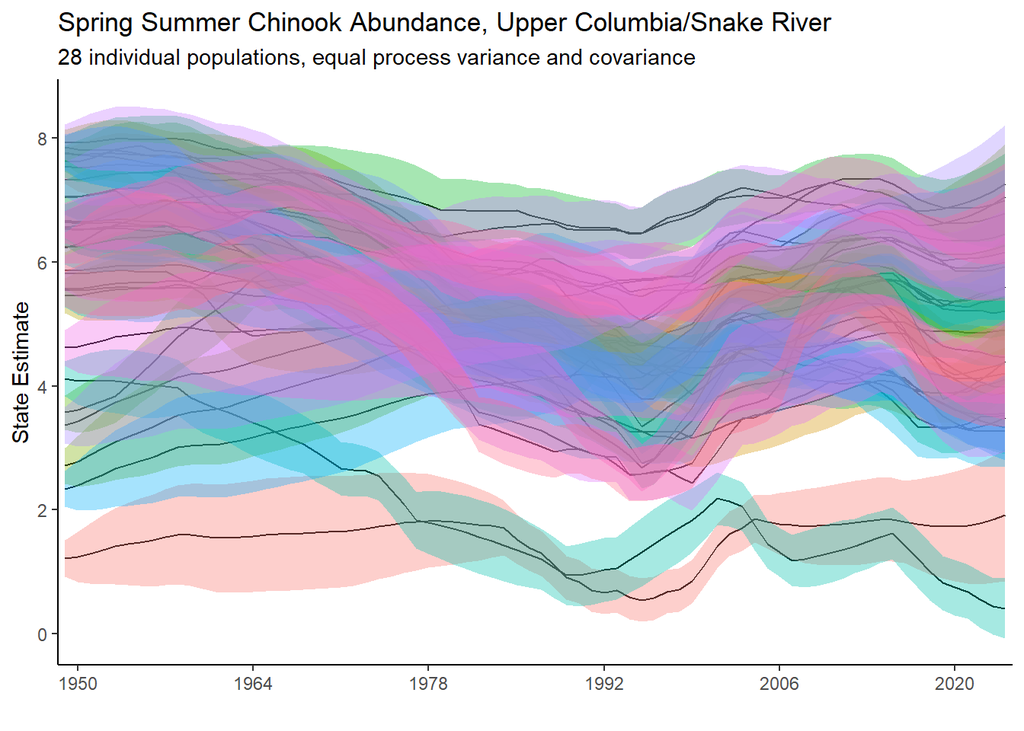

### Model 4a with PDO

Hypothesis 4a considers all 28 populations as samples from three distinct underlying state process representing different run timing. Each of these runs is modeled with the same variance and equal covariance, and with PDO covariates included.

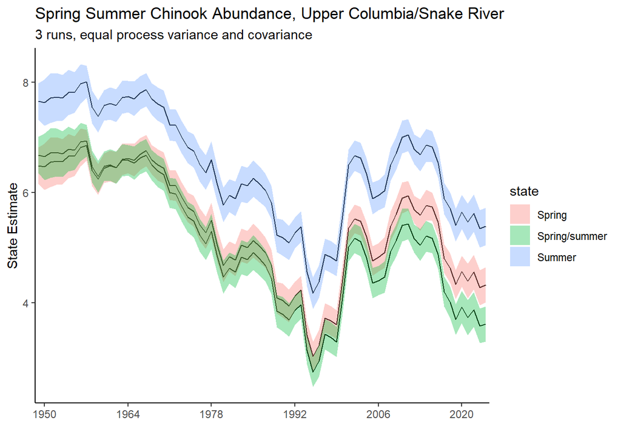

### Model Comparison

```
##      Model     AICc
## 1    fit.3 2094.651
## 2 PDOfit.3 2591.985
```

```
##       Model     AICc
## 1    fit.4a 2100.727
## 2 PDOfit.4a 2959.278
```

In both cases including PDO covariates does not improve model fit. This is a somewhat surprising finding, but is likely the benefit of the new information the covariates provide not outweighing the cost introducing additional parameters.

# Discussion

The AICc values reported in the Results section suggests that the best model for the data is the fully separated one identified in H3, where all 28 populations are separated, however temporally correlated. This is followed closely by H4a, where the populations are separated only by run timing and are temporally correlated. These two findings are consistent with what we would expect ecologically, as the 28 separate populations have likely developed similarities in behavior at sea and during migration homewards. Similarly, it is not surprising to see that run timing is the next best model. This also makes sense ecologically because the timing of the run determines the migration pattern, route, and schooling tendencies of the particular group, which would likely mean they are surviving and returning in similar ways to that of their cohort. Somewhat surprisingly, the inclusion of pacific decadal oscilation data as covariates does not improve the fit of either model.

An interesting comparison can be drawn between H4a and H4b when considering the influence of covariance on the model behavior in this case. In H4a, with covariance, we see a strong similarity between the state estimates of the Spring/Summer run and the Summer run, however when we look at the same model without covariance in H4b, we see a far different trend in the Summer run state estimates. The Summer run model in H4b acts a lot differently, showing a ‘smoother’ state estimate that is not tied to the other groups to the same degree, allowing for greater independence between the three groups. The same can be observed for H5a and H5b, where the effect of covariance on the data in H5a is incredibly strong and visible in the shape of the state estimates over time, compared to the more smooth and loose appearance in 5b.

# Description of each team member’s contributions

Example: All team members met together twice to talk about goals and how to divide work. Brian designed the code and question for the first and third question and Emma designed and contributed code for the second question about population grouping. All members contributed to the discussion and writing of the report.